# Análisis exploratorio (ejecuciones)

Andrés Millán

Paula Villanueva

30 diciembre, 2021

# 1 Análisis exploratorio univariante

Se ha elegido el fichero de datos `DB_2.sav`. La información del dataset es la siguiente:

> Un grupo constituido por 13 empresas se ha clasificado según las puntuaciones obtenidas en 8 indicadores económicos:
> - X1: Indicador de volumen de facturación.
> - X2: Indicador de nivel de nueva contratación.
> - X3: Indicador del total de clientes.
> - X4: Indicador de beneficios de la empresa .
> - X5: Indicador de retribución salarial de los empleados.
> - X6: Indicador de organización empresarial dentro de la empresa.
> - X7: Indicador de relaciones con otras empresas.
> - X8: Indicador de nivel de equipamiento (ordenadores, maquinaria, etc…).

Comenzamos cargando la base de datos con el siguiente comando y mostramos los datos que contiene.

```r
library(foreign)
datos <- read.spss("./datasets/DB_2.sav", to.data.frame = TRUE, reencode = "utf-8")
```

```
## re-encoding from utf-8
```

```r
datos
```

```
##              x1         x2        x3          x4        x5        x6        x7
## 1  1.279554e-01  0.9444263  2.166667  5.79433292  5.480291 11.096322  3.982094
## 2  1.552544e+00  4.2996830  4.333333  5.40439487  5.335612 11.011499  5.584143
## 3  1.214796e+00  6.8997865  6.500000  4.06727850  6.889363 24.763075  7.276582
## 4  2.475883e+00  8.6930622  8.666667  7.40941778  4.137916 31.585770 10.339785
## 5  6.013061e+00 11.2399245 10.833333  0.02990288 10.036760 10.169836  1.966363
## 6  6.735028e+00 13.1271733 13.000000  1.54954845  5.874234  6.134638  1.063619
## 7  7.583921e+00 14.8487119 15.166667 11.39590764  2.709851  6.955054  1.667021
## 8  8.014212e+00 18.1598131 17.333333  6.32676834  2.556536 41.523867 12.373881
## 9  8.119725e+00 19.5660634 19.500000  6.51471573  3.462434 31.037808 10.160371
## 10 1.151672e+01 21.7261519 21.666667  5.06008196  5.918977 43.278324 12.235597
## 11 1.073365e+01 24.1410834 23.833333  3.96939242  5.595512 11.374130  5.236333
## 12 1.198526e+01 24.8071237 26.000000  4.88552952  4.870252  9.709267  4.088848
## 13 1.436357e+01 25.4261297 28.166667  7.76111352  3.524603 34.436416  9.798433
## 14 2.002300e+04 18.0000000 16.000000  8.00000000  8.000000 10.000000        NA
##           x8
## 1   5.798710
## 2   8.102565
## 3  14.398706
## 4  17.872456
## 5   7.550620
## 6   3.948938
## 7   4.750391
## 8  26.231918
## 9  20.154125
## 10 26.571424
## 11  7.333438
## 12  6.832688
## 13 20.413416
## 14        NA
```

Según el problema, hay 13 empresas pero observamos que hay 14 filas. Esto nos hace sospechar que hay una fila errónea.

## 1.1 Recodificaciones

No es necesario recodificar o agrupar los datos, pues como observamos en el archivo de datos, tenemos que todas las variables son numéricas.

## 1.2 Valores perdidos

Veamos los estadísticos descriptivos básicos con el siguiente comando.

```r
summary(datos)
```

```
##        x1                  x2                x3               x4
##  Min.   :    0.128   Min.   : 0.9444   Min.   : 2.167   Min.   : 0.0299
##  1st Qu.:    3.360   1st Qu.: 9.3298   1st Qu.: 9.208   1st Qu.: 4.2718
##  Median :    7.799   Median :16.4244   Median :15.583   Median : 5.5994
##  Mean   : 1436.674   Mean   :15.1342   Mean   :15.226   Mean   : 5.5835
##  3rd Qu.:   11.321   3rd Qu.:21.1861   3rd Qu.:21.125   3rd Qu.: 7.1857
##  Max.   :20023.000   Max.   :25.4261   Max.   :28.167   Max.   :11.3959
##
##        x5               x6               x7               x8
##  Min.   : 2.557   Min.   : 6.135   Min.   : 1.064   Min.   : 3.949
##  1st Qu.: 3.678   1st Qu.:10.042   1st Qu.: 3.982   1st Qu.: 6.833
##  Median : 5.408   Median :11.235   Median : 5.584   Median : 8.103
##  Mean   : 5.314   Mean   :20.220   Mean   : 6.598   Mean   :13.074
##  3rd Qu.: 5.908   3rd Qu.:31.449   3rd Qu.:10.160   3rd Qu.:20.154
##  Max.   :10.037   Max.   :43.278   Max.   :12.374   Max.   :26.571
##                                    NA's   :1        NA's   :1
```

Además, nos llama la atención que la media de la variable `x1` obtenga un valor demasiado elevado. Esto se debe a que en la fila 14 hay un valor muy grande y hace que se alteren las medidas que resumen a las variables. Asimismo, como habíamos mencionado antes, la fila 14 es la que tiene los valores perdidos y, como todo indica que las primeras 13 filas corresponden a las 13 primeras empresas, procedemos a eliminar esta última fila con el siguiente comando.

```r
datos <- datos[-14, ]
colSums(is.na(datos))
```

```
## x1 x2 x3 x4 x5 x6 x7 x8
##  0  0  0  0  0  0  0  0
```

Como no tenemos más valores perdidos en el dataset, no necesitamos analizar el patrón aleatorio de éstos ni cómo imputarlos.

## 1.3 Análisis descriptivo numérico clásico

Hasta ahora, el resumen de los datos que tenemos es el siguiente.

```r
summary(datos)
```

```
##        x1               x2                x3               x4
##  Min.   : 0.128   Min.   : 0.9444   Min.   : 2.167   Min.   : 0.0299
##  1st Qu.: 2.476   1st Qu.: 8.6931   1st Qu.: 8.667   1st Qu.: 4.0673
##  Median : 7.584   Median :14.8487   Median :15.167   Median : 5.4044
##  Mean   : 6.957   Mean   :14.9138   Mean   :15.167   Mean   : 5.3976
##  3rd Qu.:10.734   3rd Qu.:21.7262   3rd Qu.:21.667   3rd Qu.: 6.5147
##  Max.   :14.364   Max.   :25.4261   Max.   :28.167   Max.   :11.3959
##        x5               x6               x7               x8
##  Min.   : 2.557   Min.   : 6.135   Min.   : 1.064   Min.   : 3.949
##  1st Qu.: 3.525   1st Qu.:10.170   1st Qu.: 3.982   1st Qu.: 6.833
##  Median : 5.336   Median :11.374   Median : 5.584   Median : 8.103
##  Mean   : 5.107   Mean   :21.006   Mean   : 6.598   Mean   :13.074
##  3rd Qu.: 5.874   3rd Qu.:31.586   3rd Qu.:10.160   3rd Qu.:20.154
##  Max.   :10.037   Max.   :43.278   Max.   :12.374   Max.   :26.571
```

Con el siguiente comando crearemos un boxplot para ver cómo es la distribución de las variables.

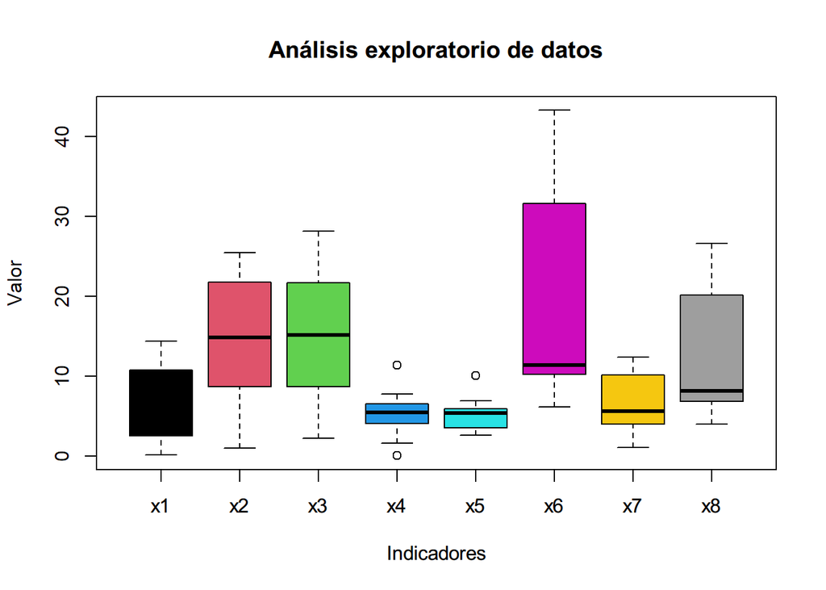

```r
boxplot (
  datos,
  main = "Análisis exploratorio de datos",
  xlab = "Indicadores",
  ylab = "Valor",
  col = c(1 : 15)
)
```

Además, para obtener el coeficiente de simetría utilizaremos el comando `skewness`.

https://www.programmingr.com/statistics/skewness/

```r
library(moments)
skewness(datos)
```

```
##            x1            x2            x3            x4            x5
## -6.571128e-02 -2.178143e-01  2.441493e-16  8.611432e-02  9.539367e-01
##            x6            x7            x8
##  4.214678e-01  1.014152e-01  4.874442e-01
```

## 1.4 Valores extremos

Utilizamos la función [`check_outliers`](https://www.rdocumentation.org/packages/performance/versions/0.8.0/topics/check_outliers) para comprobar si hay outliers:

```r
library("performance")
check_outliers(datos, method = "mahalanobis")
```

```
## OK: No outliers detected.
```

Aunque en el boxplot anterior sí que se indican posibles valores outliers, utilizando el método de mahalanobis no sale nada. Por tanto, los dejaremos en el conjunto de datos.

## 1.5 Supuesto de normalidad

Comprobamos si los datos están normalizados (es decir, media 0 y varianza 1). Para ello, calculamos la media y la desviación típica de cada variable con los siguientes comandos.

```r
round(colMeans(datos), 5)
```

```
##       x1       x2       x3       x4       x5       x6       x7       x8
##  6.95664 14.91378 15.16667  5.39757  5.10710 21.00585  6.59793 13.07380
```

```r
round(apply(datos, 2, sd), 5)
```

```
##       x1       x2       x3       x4       x5       x6       x7       x8
##  4.54510  8.16260  8.43795  2.82382  1.99191 13.77978  4.03066  8.24973
```

No lo están, así que los normalizamos:

```r
datos_normalizados <- scale(datos)
datos_normalizados
```

```
##             x1           x2         x3           x4         x5         x6
## 1  -1.50242823 -1.711385214 -1.5406578  0.140506528  0.1873516 -0.7191350
## 2  -1.18899425 -1.300332773 -1.2838815  0.002417587  0.1147183 -0.7252906
## 3  -1.26330459 -0.981794137 -1.0271052 -0.471096039  0.8947487  0.2726624
## 4  -0.98584384 -0.762099962 -0.7703289  0.712457264 -0.4865617  0.7677858
## 5  -0.20760372 -0.450083911 -0.5135526 -1.900853708  2.4748383 -0.7863701
## 6  -0.04875864 -0.218877091 -0.2567763 -1.362700930  0.3851232 -1.0792047
## 7   0.13801253 -0.007971427  0.0000000  2.124194733 -1.2034938 -1.0196671
## 8   0.23268386  0.397671523  0.2567763  0.329058125 -1.2804625  1.4889943
## 9   0.25589851  0.569951225  0.5135526  0.395616020 -0.8256742  0.7280202
## 10  1.00329513  0.834583629  0.7703289 -0.119514100  0.4075857  1.6163154
## 11  0.83100753  1.130436851  1.0271052 -0.505760483  0.2451960 -0.6989744
## 12  1.10638340  1.212033431  1.2838815 -0.181328435 -0.1189064 -0.8197936
## 13  1.62965231  1.287867855  1.5406578  0.837003438 -0.7944632  0.9746574
##            x7         x8
```

[output cut: 19 more lines]

Y ahora, podemos comprobar que lo están:

```r
round(colMeans(datos_normalizados), 5)
```

```
## x1 x2 x3 x4 x5 x6 x7 x8
##  0  0  0  0  0  0  0  0
```

```r
round(apply(datos_normalizados, 2, sd), 5)
```

```
## x1 x2 x3 x4 x5 x6 x7 x8
##  1  1  1  1  1  1  1  1
```

Además, podemos hacer uso del gráfico qqplot para mostrar si hay normalidad:

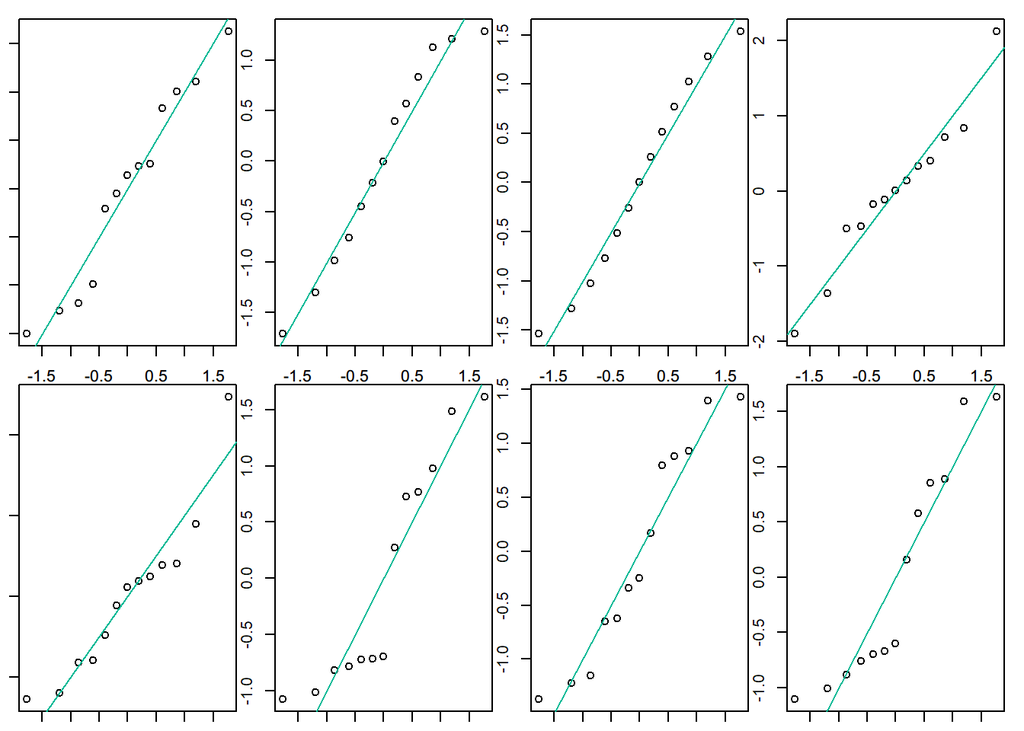

```r
par(mar = c(1, 1, 1, 1))
par(mfrow = c(2, 4))

invisible(apply(datos_normalizados, 2, function(x) {
  qqnorm(x, main = NULL)
  abline(a = 0, b = 1, col = "#00b894")
}))
```

# 2 Análisis exploratorio multivariante

```r
datos_pca <- datos_normalizados
```

## 2.1 Correlación entre variables (test de Bartlett)

Comprobamos si existe correlación entre las variables usando el test de Bartlett.

```r
library("psych")
cortest.bartlett(cor(datos_pca), nrow(datos_pca))
```

```
## $chisq
## [1] 154.2293
##
## $p.value
## [1] 2.122684e-19
##
## $df
## [1] 28
```

Observamos que obtenemos un `p-value` prácticamente nulo, por lo que esto indica que las variables están correladas. De esta forma, procederemos a realizar un Análisis de Componentes Principales (ACP).

```r
round(cor(datos_pca), 5)
```

```
##          x1       x2       x3       x4       x5       x6       x7       x8
## x1  1.00000  0.97223  0.98051  0.10284 -0.25750  0.26429  0.21419  0.29880
## x2  0.97223  1.00000  0.99400  0.11299 -0.30798  0.31223  0.29330  0.34787
## x3  0.98051  0.99400  1.00000  0.14787 -0.32614  0.29842  0.27949  0.32854
## x4  0.10284  0.11299  0.14787  1.00000 -0.84094  0.25150  0.29578  0.22939
## x5 -0.25750 -0.30798 -0.32614 -0.84094  1.00000 -0.34828 -0.41550 -0.34282
## x6  0.26429  0.31223  0.29842  0.25150 -0.34828  1.00000  0.96658  0.99404
## x7  0.21419  0.29330  0.27949  0.29578 -0.41550  0.96658  1.00000  0.96319
## x8  0.29880  0.34787  0.32854  0.22939 -0.34282  0.99404  0.96319  1.00000
```

## 2.2 Tratar outliers si no se ha hecho antes

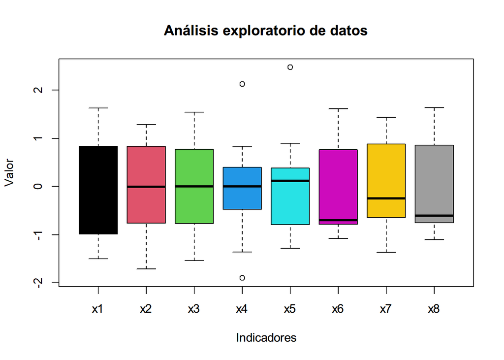

```r
boxplot (
  datos_pca,
  main = "Análisis exploratorio de datos",
  xlab = "Indicadores",
  ylab = "Valor",
  col = c(1 : 15)
)
```

```r
check_outliers(datos_pca, method = "mahalanobis")
```

```
## OK: No outliers detected.
```

```r
outlier <- function(data, na_rm = T) {
        H <- 1.5 * IQR(data)
        data[data < quantile(data, 0.25, na.rm = T) - H] <- NA
        data[data > quantile(data, 0.75, na.rm = T) + H] <- NA
        data[is.na(data)] <- mean(data, na.rm = T)
        data
}

#datos_pca <- apply(datos_pca, 2, outlier)
```

```r
datos_pca
```

```
##             x1           x2         x3           x4         x5         x6
## 1  -1.50242823 -1.711385214 -1.5406578  0.140506528  0.1873516 -0.7191350
## 2  -1.18899425 -1.300332773 -1.2838815  0.002417587  0.1147183 -0.7252906
## 3  -1.26330459 -0.981794137 -1.0271052 -0.471096039  0.8947487  0.2726624
## 4  -0.98584384 -0.762099962 -0.7703289  0.712457264 -0.4865617  0.7677858
## 5  -0.20760372 -0.450083911 -0.5135526 -1.900853708  2.4748383 -0.7863701
## 6  -0.04875864 -0.218877091 -0.2567763 -1.362700930  0.3851232 -1.0792047
## 7   0.13801253 -0.007971427  0.0000000  2.124194733 -1.2034938 -1.0196671
## 8   0.23268386  0.397671523  0.2567763  0.329058125 -1.2804625  1.4889943
## 9   0.25589851  0.569951225  0.5135526  0.395616020 -0.8256742  0.7280202
## 10  1.00329513  0.834583629  0.7703289 -0.119514100  0.4075857  1.6163154
## 11  0.83100753  1.130436851  1.0271052 -0.505760483  0.2451960 -0.6989744
## 12  1.10638340  1.212033431  1.2838815 -0.181328435 -0.1189064 -0.8197936
## 13  1.62965231  1.287867855  1.5406578  0.837003438 -0.7944632  0.9746574
##            x7         x8
```

[output cut: 19 more lines]

## 2.3 Análisis de componentes principales

Realizamos el ACP con la siguiente función.

```r
PCA <- prcomp(datos_pca, scale = T, center = T)
```

El campo `rotation` del objeto `PCA` es una matriz cuyas columnas son los coeficientes de las componentes principales. Esto es, podemos ver el peso de cada variable en la correspondiente componente principal.

```r
PCA$rotation
```

```
##           PC1        PC2          PC3          PC4        PC5         PC6
## x1  0.3551455 -0.4595062  0.033601105 -0.176609930  0.4258306  0.60704157
## x2  0.3768876 -0.4287535  0.037472654  0.071741723 -0.2652286 -0.57779826
## x3  0.3762612 -0.4335531  0.005787864 -0.004854737 -0.2369191 -0.01819360
## x4  0.2139962  0.2020897 -0.671802994 -0.664124709 -0.1269336 -0.05405306
## x5 -0.2942257 -0.1420473  0.598358307 -0.698479047 -0.2143726 -0.02738392
## x6  0.3895227  0.3442997  0.262896005 -0.118810866  0.2981424 -0.16345744
## x7  0.3859174  0.3671744  0.205816032  0.125086198 -0.6499635  0.45290321
## x8  0.3965243  0.3204361  0.276779320 -0.070294400  0.3446480 -0.24861098
##            PC7          PC8
## x1 -0.17900395  0.220299901
## x2 -0.26457545  0.439747586
## x3  0.45463945 -0.638156278
## x4 -0.04385130  0.005261391
## x5 -0.02507433 -0.003728128
## x6  0.63972628  0.348772854
## x7 -0.13567768  0.110732312
## x8 -0.51093109 -0.465726153
```

Además, con el campo `sdev` del objeto `PCA` y con la función `summary` aplicada al objeto, obtenemos las desviaciones típicas de cada componente principal y la proporción de varianza explicada y acumulada.

```r
PCA$sdev
```

```
## [1] 2.04990363 1.45942303 1.20529697 0.38124395 0.21872628 0.11807220 0.08063033
## [8] 0.04010383
```

```r
summary(PCA)
```

```
## Importance of components:
##                           PC1    PC2    PC3     PC4     PC5     PC6     PC7
## Standard deviation     2.0499 1.4594 1.2053 0.38124 0.21873 0.11807 0.08063
## Proportion of Variance 0.5253 0.2662 0.1816 0.01817 0.00598 0.00174 0.00081
## Cumulative Proportion  0.5253 0.7915 0.9731 0.99126 0.99724 0.99899 0.99980
##                           PC8
## Standard deviation     0.0401
## Proportion of Variance 0.0002
## Cumulative Proportion  1.0000
```

Con el siguiente comando hacemos un análisis gráfico de la varianza explicada.

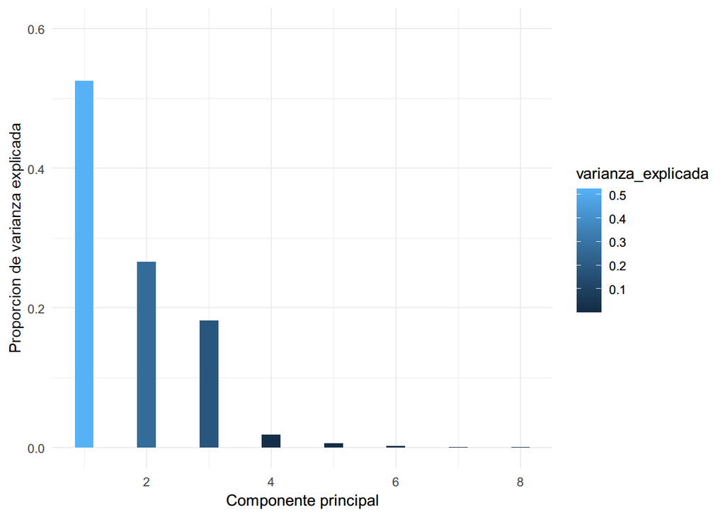

```r
library(ggplot2)
varianza_explicada <- PCA$sdev^2 / sum(PCA$sdev^2)
ggplot(
  data = data.frame(varianza_explicada, pc = 1:8),
  aes(x = pc, y = varianza_explicada, fill = varianza_explicada)
) + geom_col(width = 0.3) +
    scale_y_continuous(limits = c(0,0.6)) +
    theme_minimal() +
    labs(x = "Componente principal", y= "Proporcion de varianza explicada")
```

Con el siguiente comando hacemos un análisis gráfico de la varianza explicada.

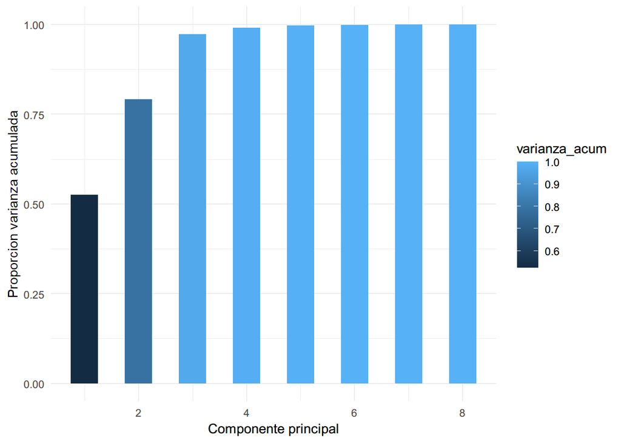

```r
varianza_acum <- cumsum(varianza_explicada)
ggplot(
  data = data.frame(varianza_acum, pc = 1:8),
  aes(x = pc, y = varianza_acum ,fill=varianza_acum )
) + geom_col(width = 0.5) +
    scale_y_continuous(limits = c(0,1)) +
    theme_minimal() +
    labs(x = "Componente principal", y = "Proporcion varianza acumulada")
```

### 2.3.1 Reducción de dimensión mediante variables observables

En esta sección seleccionaremos el número de componentes principales óptimo.

Para ello, se promedian las varianzas explicadas por las componentes principales y se seleccionan aquellas cuya proporción de varianza explicada supera la media.

Calculamos la varianza con el siguiente comando.

```r
PCA$sdev^2
```

```
## [1] 4.202104878 2.129915588 1.452740792 0.145346946 0.047841185 0.013941044
## [7] 0.006501250 0.001608317
```

Calculamos el promedio de la varianza con la siguiente función.

```r
mean(PCA$sdev^2)
```

```
## [1] 1
```

Por lo que nos quedaremos con las **tres primeras componentes principales**, pues son las que su proporción de varianza explicada supera la media, que es 1.

Además, para afianzar esta decisión, podemos hacer uso del método del codo, como se indica a continuación.

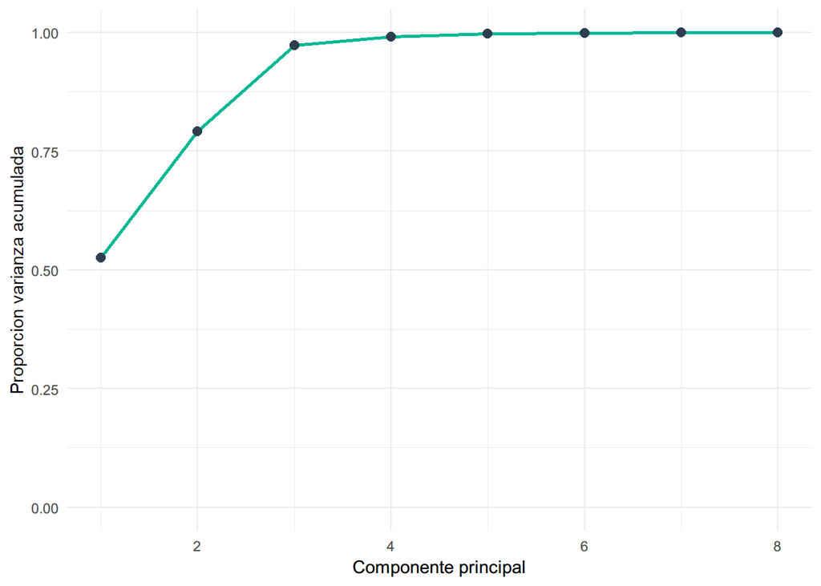

```r
ggplot(
  data = data.frame(varianza_acum, pc = 1:8),
  aes(x = pc, y = varianza_acum)
) + geom_line(size = 1, colour = "#00b894") +
    geom_point(size = 2.5, colour = "#2c3e50") +
    scale_y_continuous(limits = c(0, 1)) +
    theme_minimal() +
    labs(x = "Componente principal", y = "Proporcion varianza acumulada")
```

### 2.3.2 Visualización de las contribuciones a las dimensiones principales

En este apartado veremos la representación conjunta de variables y observaciones que relaciona visualmente las posibles relaciones entre las observaciones, las contribuciones de los individuos a las varianzas de las componentes y el peso de las variables en cada componentes principal.

Variables y observaciones en la primera y segunda componente principal:

```r
library("factoextra")
```

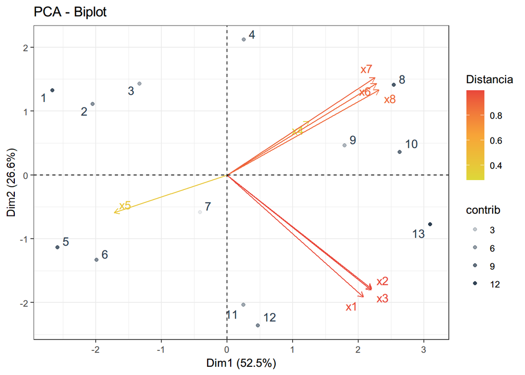

```r
fviz_pca(
  PCA,
  axes = c(1, 2),
  alpha.ind = "contrib",
  col.var = "cos2", col.ind = "#2c3e50",
  gradient.cols = c("#ddd839", "#f7a438", "#e9473b"),
  repel = TRUE,
  legend.title = "Distancia"
) + theme_bw()
```

Variables y observaciones en la primera y tercera componente principal:

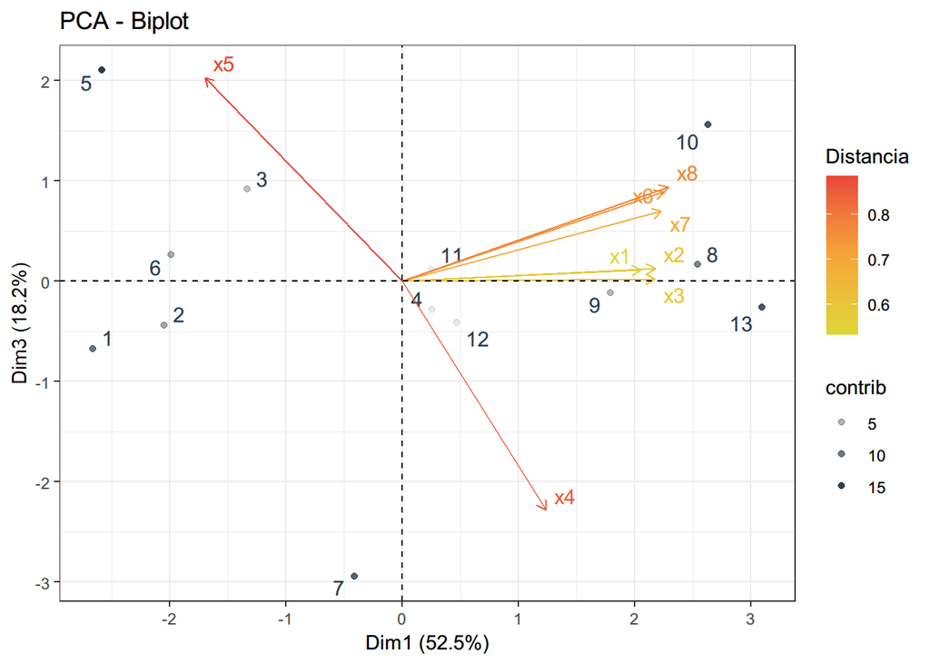

```r
fviz_pca(
  PCA,
  axes = c(1, 3),
  alpha.ind = "contrib",
  col.var = "cos2",
  col.ind = "#2c3e50",
  gradient.cols = c("#ddd839", "#f7a438", "#e9473b"),
  repel = TRUE,
  legend.title = "Distancia"
) + theme_bw()
```

Variables y observaciones en la segunda y tercera componente principal:

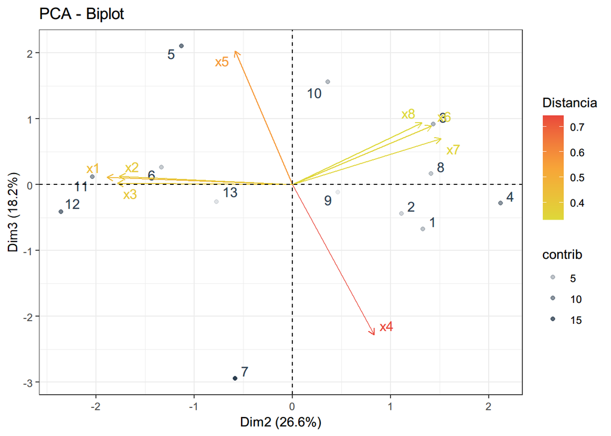

```r
fviz_pca(
  PCA,
  axes = c(2, 3),
  alpha.ind = "contrib",
  col.var = "cos2",
  col.ind = "#2c3e50",
  gradient.cols = c("#ddd839", "#f7a438", "#e9473b"),
  repel = TRUE,
  legend.title = "Distancia"
  ) + theme_bw()
```

## 2.4 Análisis factorial (variables latentes)

Ya hemos visto que las variables están correladas, luego tiene sentido el AF.

Obtenemos una representación visual de las correlaciones. Calculamos la matriz de correlaciones policórica.

```r
library("polycor")
```

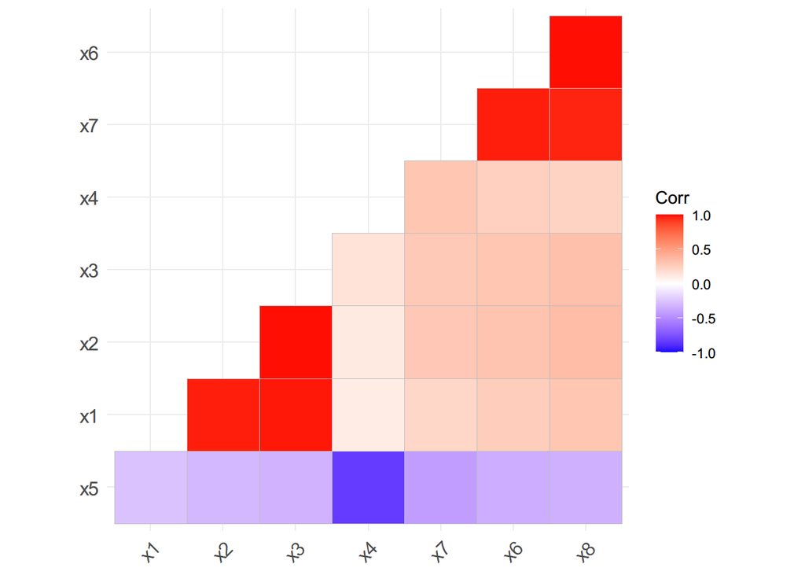

```r
library("ggcorrplot")
datos_af <- datos_normalizados
poly_cor <- hetcor(datos_af)$correlations
ggcorrplot(poly_cor, type = "lower", hc.order = T)
```

```r
modelo1 <- fa(
  poly_cor,
  nfactors = 3,
  rotate = "none",
  fm = "mle"
) # modelo máxima verosimilitud
```

```r
modelo2 <- fa(
  poly_cor,
  nfactors = 3,
  rotate = "none",
  fm = "minres"
) # modelo mínimo residuo
```

Comparamos las comunalidades.

```r
sort(modelo1$communality,decreasing = T) -> c1
sort(modelo2$communality,decreasing = T) -> c2
head(cbind(c1,c2))
```

```
##           c1        c2
## x3 0.9957117 0.9979017
## x8 0.9950126 0.9959906
## x6 0.9946399 0.9943552
## x2 0.9925314 0.9941048
## x1 0.9642011 0.9894615
## x7 0.9462238 0.9628831
```

Comparamos las unicidades, es decir, la proporción de varianza que no ha sido explicada por el factor (1-comunalidad).

```r
sort(modelo1$uniquenesses, decreasing = T) -> u1
sort(modelo2$uniquenesses, decreasing = T) -> u2
head(cbind(u1,u2))
```

```
##             u1          u2
## x4 0.191478071 0.271443843
## x5 0.093244377 0.053138550
## x7 0.053776165 0.037116900
## x1 0.035798901 0.010538529
## x2 0.007468638 0.005895229
## x6 0.005360148 0.005644811
```

Determinamos el número óptimo de factores.

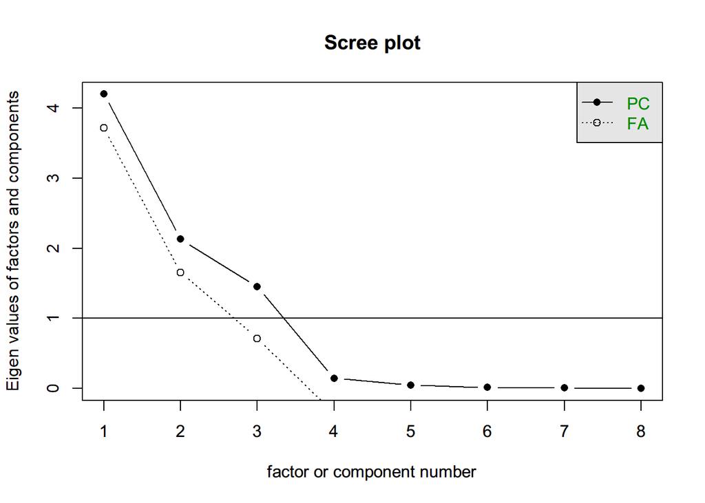

```r
scree(poly_cor)
```

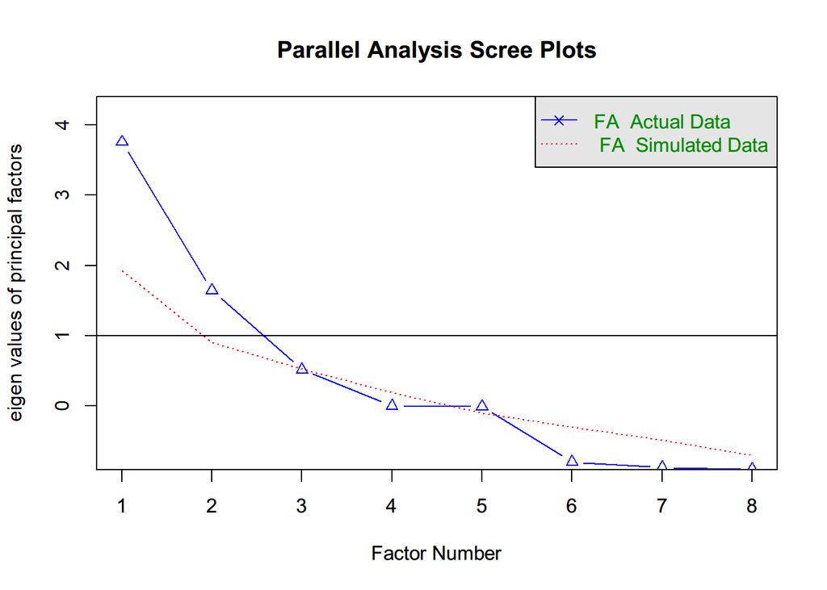

```
## Parallel analysis suggests that the number of factors =  2  and the number of components =  NA
```

```r
fa.parallel(poly_cor, n.obs = 13, fa = "fa", fm = "mle")
```

Estimamos el modelo factorial con 3 factores implementando una rotación tipo varimax para buscar una interpretación más simple.

```r
modelo_varimax <- fa(poly_cor, nfactors = 3, rotate = "varimax", fa = "mle")
```

Mostramos la matriz de pesos factorial rotada.

```r
print(modelo_varimax$loadings, cut = 0)
```

```
##
## Loadings:
##    MR2    MR1    MR3
## x1  0.973  0.113  0.064
## x2  0.976  0.170  0.089
## x3  0.981  0.148  0.121
## x4  0.026  0.130  0.843
## x5 -0.185 -0.202 -0.960
## x6  0.142  0.978  0.135
## x7  0.111  0.944  0.208
## x8  0.179  0.974  0.116
##
##                 MR2   MR1   MR3
## SS loadings    2.96 2.917 1.733
## Proportion Var 0.37 0.365 0.217
## Cumulative Var 0.37 0.735 0.951
```

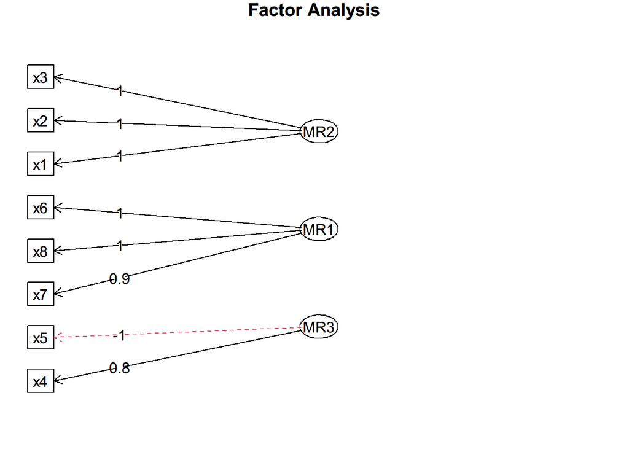

```r
fa.diagram(modelo_varimax)
```

Veamos con el test de hipótesis que contrasta si el número de factores es suficiente.

```r
library(stats)
factanal(datos_af, factors = 3, rotation="none")
```

```
##
## Call:
## factanal(x = datos_af, factors = 3, rotation = "none")
##
## Uniquenesses:
##    x1    x2    x3    x4    x5    x6    x7    x8
## 0.036 0.007 0.005 0.192 0.093 0.005 0.054 0.005
##
## Loadings:
##    Factor1 Factor2 Factor3
## x1  0.723   0.663
## x2  0.766   0.637
## x3  0.756   0.651
## x4  0.247           0.861
## x5 -0.419          -0.855
## x6  0.847  -0.526
## x7  0.816  -0.523
## x8  0.865  -0.497
##
##                Factor1 Factor2 Factor3
## SS loadings      4.049   2.072   1.483
## Proportion Var   0.506   0.259   0.185
## Cumulative Var   0.506   0.765   0.950
##
## Test of the hypothesis that 3 factors are sufficient.
## The chi square statistic is 8.8 on 7 degrees of freedom.
## The p-value is 0.267
```

## 2.5 Análisis de la normalidad multivariante

El paquete MVN contiene funciones que permiten realizar los test que se utilizan habitualmente para contrastar la normalidad multivariante. Además, podemos analizar los outliers con funciones de este paquete.

```r
library(MVN)
hz_test <- mvn(data = datos_pca, mvnTest = "hz", multivariateOutlierMethod = "quan")
```

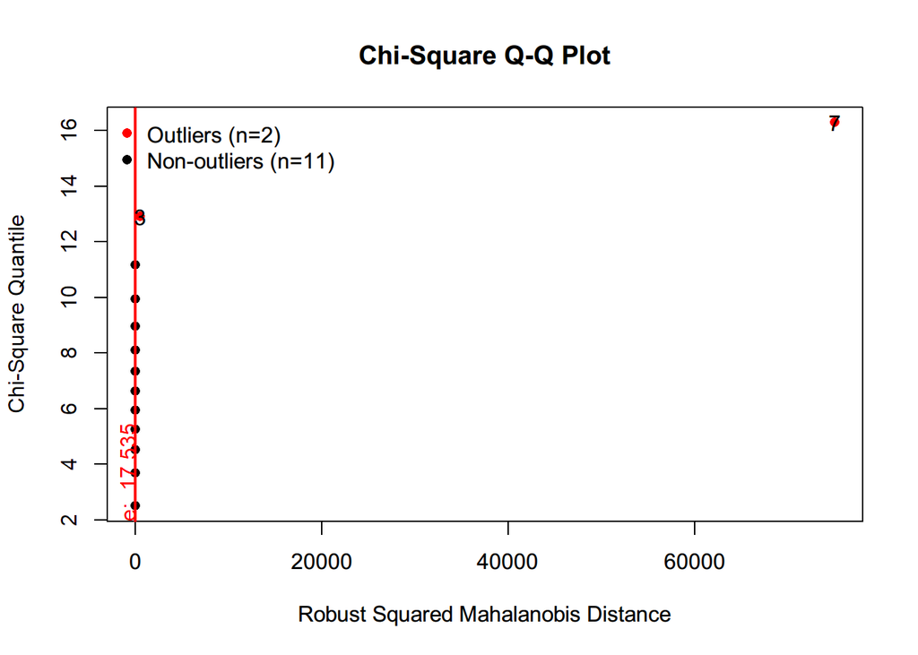

Se detectan 2 outliers en las observaciones 3 y 7. Sin embargo ninguno de los dos test realizados a continuación encuentran evidencias al 5% de significación de falta de normalidad multivariante.

A continuación realizamos el test de Royston.

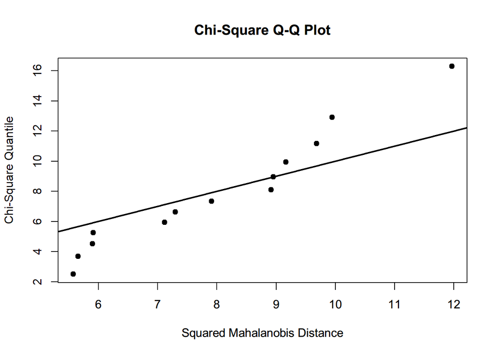

```r
royston_test <- mvn(data = datos_pca, mvnTest = "royston", multivariatePlot = "qq")
```

```r
royston_test$multivariateNormality
```

```
##      Test        H   p value MVN
## 1 Royston 5.524612 0.1604468 YES
```

El test de Henze-Zirkler es el siguiente.

```r
hz_test <- mvn(data = datos[, -1], mvnTest = "hz")
hz_test$multivariateNormality
```

```
##            Test        HZ   p value MVN
## 1 Henze-Zirkler 0.9051215 0.1572768 YES
```

Ambos nos dicen que siguen una normal multivariante.

## 2.6 Clasificador mediante análisis discriminante

```r
knitr::purl("./Ejecución.rmd")
```

[output not shown]

[output not shown]

[output cut: 36 more lines]

[output not shown]

```
## output file: Ejecución.R
```

```
## [1] "Ejecución.R"
```